# 0718morning

CARTUS YOU

2018年7月19日

# BASIC ASSUMPTIONS:

### If there is a major disaster happening in the interval, then there should be relatively more emergency allowances in that interval, since the press would report the major disaster more often, and the public woulb more concern about the victims, which could urge the government increasing the emergency allowance.

> Preparation
- Set the working direction and import data.

```r
setwd('D:/2018.07 R_DataAnalysis/2018SUMMER_R/data')

library(readr)
DN <- read_csv("Disaster_NewTaipei.csv")
DNH <- read_csv("Disaster_NewTaipei_Help.csv")
```

> Organizing Data
- Turn the time in DN into form as ‘xxx.xx’.
- Create weighted sum by Multiplicating.

```r
DN$occurrence_time <- substring(as.character(DN$occurrence_time),1,6)
DN$weighted <- as.numeric(as.character(unlist(5*DN[5]+2*DN[6]+2*DN[7]+4*DN[8])))
```

*Create start month and end month for each interval.

```r
season <- c(' 全年', ' 第一季', ' 第二季', ' 第三季', ' 第四季')
s_month <- c('.01', '.01', '.04', '.07', '.10')
e_month <- c('.12', '.03', '.06', '.09', '.12')

DNH$startmonth <- gsub(season[1], s_month[1], as.character(DNH$期間))
DNH$startmonth <- gsub(season[2], s_month[2], as.character(DNH$startmonth))
DNH$startmonth <- gsub(season[3], s_month[3], as.character(DNH$startmonth))
DNH$startmonth <- gsub(season[4], s_month[4], as.character(DNH$startmonth))
DNH$startmonth <- gsub(season[5], s_month[5], as.character(DNH$startmonth))
DNH$startmonth <- as.numeric(DNH$startmonth) - 1911

DNH$endmonth <- gsub(season[1], e_month[1], as.character(DNH$期間))
DNH$endmonth <- gsub(season[2], e_month[2], as.character(DNH$endmonth))
DNH$endmonth <- gsub(season[3], e_month[3], as.character(DNH$endmonth))
DNH$endmonth <- gsub(season[4], e_month[4], as.character(DNH$endmonth))
DNH$endmonth <- gsub(season[5], e_month[5], as.character(DNH$endmonth))
DNH$endmonth <- as.numeric(DNH$endmonth) - 1911
head(DNH)
```

```
## # A tibble: 6 x 15
##   期間     災害次數_次 收容所_所數_所 收容所_臨時收容災民數_人_~ 受災人數_人__合計~
##   <chr>          <int>          <int>               <int>            <int>
## 1 2011 全年~          59              0                   0               21
## 2 2011 第一~          21              0                   0                7
## 3 2011 第二~          15              0                   0                6
## 4 2011 第三~           6              0                   0                0
## 5 2011 第四~          17              0                   0                8
## 6 2012 全年~          85              0                   0               19
## # ... with 10 more variables: 受災人數_人__死亡 <int>,
## #   受災人數_人__失蹤 <int>, 受災人數_人__重傷 <int>,
## #   受災人數_人__其他 <int>, 安遷就助_戶數_戶_ <int>,
## #   安遷就助_人數_人_ <int>, 財務受損影響生計者_戶_ <int>,
## #   救助金額_新臺幣千元_ <int>, startmonth <dbl>, endmonth <dbl>
```

> Calculatation
- Find the rate of possible exaggeration due to the report by adding the percentage of disaster weighted sum in weighted sum in that interval.

```r
DNH$weighted <- as.numeric(as.character(unlist(5*DNH[6]+2*DNH[8]+2*DNH[7]+4*DNH[12])))
DNH$exag_rate <- 1
for(i in 1:nrow(DN)){
  for(j in 1:nrow(DNH)){
    if((DNH[j,14] <= DN[i,2]) && (DN[i,2] <= DNH[j,15])){
      DNH[j,17] <- (1 + (DN[i,9] / DNH[j,16]))
    }
  }
}
head(DNH)
```

```
## # A tibble: 6 x 17
##   期間     災害次數_次 收容所_所數_所 收容所_臨時收容災民數_人_~ 受災人數_人__合計~
##   <chr>          <int>          <int>               <int>            <int>
## 1 2011 全年~          59              0                   0               21
## 2 2011 第一~          21              0                   0                7
## 3 2011 第二~          15              0                   0                6
## 4 2011 第三~           6              0                   0                0
## 5 2011 第四~          17              0                   0                8
## 6 2012 全年~          85              0                   0               19
## # ... with 12 more variables: 受災人數_人__死亡 <int>,
## #   受災人數_人__失蹤 <int>, 受災人數_人__重傷 <int>,
## #   受災人數_人__其他 <int>, 安遷就助_戶數_戶_ <int>,
## #   安遷就助_人數_人_ <int>, 財務受損影響生計者_戶_ <int>,
## #   救助金額_新臺幣千元_ <int>, startmonth <dbl>, endmonth <dbl>,
## #   weighted <dbl>, exag_rate <dbl>
```

- Calculate the exaggerated weighted sum and find the average of emergency allowances for each unit.

```r
DNH$exaggerated <- as.numeric(as.character(unlist(DNH$weighted * DNH$exag_rate)))
DNH$avg <- as.numeric(as.character(unlist(DNH$救助金額_新臺幣千元_ / DNH$exaggerated)))
```

> Plotting
- Plot a scatter plot with exaggerated rate and the average of emergency allowance for each unit

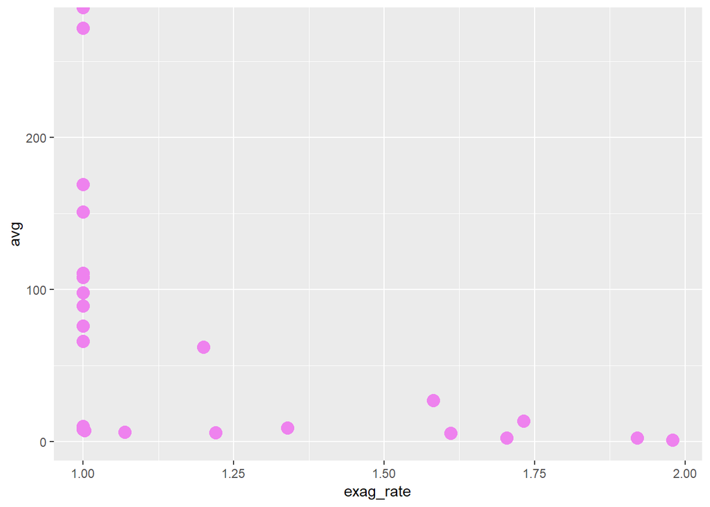

```r
library(ggplot2)
ggplot(data=DNH, aes(x=exag_rate, y=avg))+
  geom_point(color='violet', size=4)
```

# Conclusion

### The assumption is wrong because we can’t see the positive correlation in the plot.

### WHY? Probably due to 八仙塵暴&復興空難 are not natural disaster, which should be subsidize by the government

### Instead, the victims of the two disaster could ask for compensation from the company which should be responsible for.

### Thus, the compensation is not included in the data, but the amount the victims is. For the intervals which these two event happended in, though having high exaggerated rate, but the emergency allowance is not high at all.